# Visualization of disease symptoms and host density in multiple years

Wednesday, September 3rd, 2014

##### My goal is to visualize the relationship between disease symptoms caused by *Phytophthora ramorum* on California bay laurel and the density of this host tree in measured in the same plots across multiple years.

###### Load necessary libraries, loading `plyr` before `dplyr` avoids a warning.

```r
library(plyr)
library(dplyr)
library(ggplot2)
library(tidyr)
```

###### Read in each data frame, one for bay laurel density and one for bay laurel symptomatic leaf count across a number of plots, and look at the structure and summary.

```r
bay_dens <- readRDS("bay_dens.rds")
str(bay_dens)
```

```
## 'data.frame':    163 obs. of  9 variables:
##  $ plotid    : Factor w/ 163 levels "ANN02","ANN04",..: 1 2 3 4 5 6 7 8 9 10 ...
##  $ umca_ct_04: num  11 12 12 8 3 4 5 1 5 4 ...
##  $ umca_ct_05: num  11 13 15 9 3 4 5 1 5 4 ...
##  $ umca_ct_06: num  11 13 15 10 3 5 5 1 6 4 ...
##  $ umca_ct_07: num  11 13 15 10 3 5 5 1 6 4 ...
##  $ umca_ct_08: num  11 13 15 10 3 5 5 1 5 4 ...
##  $ umca_ct_09: num  11 13 14 10 3 5 5 1 5 4 ...
##  $ umca_ct_10: num  11 13 14 10 3 5 5 1 5 4 ...
##  $ umca_ct_11: num  11 13 14 10 3 5 5 1 6 4 ...
##  - attr(*, "na.action")=Class 'omit'  Named int [1:90] 164 165 166 167 168 169 170 171 172 173 ...
##   .. ..- attr(*, "names")= chr [1:90] "164" "165" "166" "167" ...
```

```r
summary(bay_dens)
```

```
##      plotid      umca_ct_04     umca_ct_05     umca_ct_06     umca_ct_07
##  ANN02  :  1   Min.   : 0.0   Min.   : 0.0   Min.   : 0.0   Min.   : 0.0
##  ANN04  :  1   1st Qu.: 3.0   1st Qu.: 3.0   1st Qu.: 3.0   1st Qu.: 3.0
##  ANN05  :  1   Median : 8.0   Median : 8.0   Median : 8.0   Median : 8.0
##  ANN06  :  1   Mean   :11.6   Mean   :11.9   Mean   :12.1   Mean   :12.1
##  ANN07  :  1   3rd Qu.:14.0   3rd Qu.:15.0   3rd Qu.:15.0   3rd Qu.:15.0
##  ANN09  :  1   Max.   :68.0   Max.   :68.0   Max.   :69.0   Max.   :69.0
##  (Other):157
##    umca_ct_08     umca_ct_09   umca_ct_10     umca_ct_11
##  Min.   : 0.0   Min.   : 0   Min.   : 0.0   Min.   : 0.0
##  1st Qu.: 3.0   1st Qu.: 3   1st Qu.: 3.0   1st Qu.: 3.0
##  Median : 8.0   Median : 8   Median : 8.0   Median : 8.0
##  Mean   :12.1   Mean   :12   Mean   :12.2   Mean   :12.4
##  3rd Qu.:15.0   3rd Qu.:15   3rd Qu.:15.0   3rd Qu.:15.0
##  Max.   :68.0   Max.   :68   Max.   :69.0   Max.   :76.0
##
```

```r
bay_slc <- readRDS("bay_slc.rds")
str(bay_slc)
```

```
## 'data.frame':    163 obs. of  9 variables:
##  $ plotid    : Factor w/ 163 levels "ANN02","ANN04",..: 1 2 3 4 5 6 7 8 9 10 ...
##  $ cum_slc_04: num  184 66 685 101 4 43 2 1 91 6 ...
##  $ cum_slc_05: num  133 89 455 1167 131 ...
##  $ cum_slc_06: num  472 138 1128 2 24 ...
##  $ cum_slc_07: num  389 542 622 649 69 178 112 2 150 118 ...
##  $ cum_slc_08: num  480 576 472 626 55 269 125 32 128 128 ...
##  $ cum_slc_09: num  657 876 506 506 73 223 120 42 123 76 ...
##  $ cum_slc_10: num  566 542 269 437 80 179 322 106 146 53 ...
##  $ cum_slc_11: num  394 272 787 540 112 159 166 19 785 107 ...
##  - attr(*, "na.action")=Class 'omit'  Named int [1:90] 164 165 166 167 168 169 170 171 172 173 ...
##   .. ..- attr(*, "names")= chr [1:90] "164" "165" "166" "167" ...
```

```r
summary(bay_slc)
```

```
##      plotid      cum_slc_04     cum_slc_05       cum_slc_06
##  ANN02  :  1   Min.   :   0   Min.   :   0.0   Min.   :   0
##  ANN04  :  1   1st Qu.:   6   1st Qu.:   2.5   1st Qu.:  24
##  ANN05  :  1   Median :  67   Median :  69.0   Median : 266
##  ANN06  :  1   Mean   : 271   Mean   : 232.8   Mean   : 594
##  ANN07  :  1   3rd Qu.: 413   3rd Qu.: 350.0   3rd Qu.: 704
##  ANN09  :  1   Max.   :2745   Max.   :1953.0   Max.   :6290
##  (Other):157
##    cum_slc_07       cum_slc_08     cum_slc_09     cum_slc_10
##  Min.   :   0.0   Min.   :   0   Min.   :   0   Min.   :   0
##  1st Qu.:  65.5   1st Qu.:  97   1st Qu.:  62   1st Qu.: 104
##  Median : 255.0   Median : 228   Median : 234   Median : 322
##  Mean   : 390.3   Mean   : 367   Mean   : 350   Mean   : 497
##  3rd Qu.: 548.0   3rd Qu.: 532   3rd Qu.: 462   3rd Qu.: 645
##  Max.   :2456.0   Max.   :2057   Max.   :2370   Max.   :4821
##
##    cum_slc_11
##  Min.   :   0
##  1st Qu.: 135
##  Median : 476
##  Mean   : 875
##  3rd Qu.:1233
##  Max.   :6485
##
```

###### The data is a bit messy, so let’s make it tidy. In a “tidy” data set each row is an obervation and each column is a variable. Read more in the `tidyr` vignette and/or the paper by Hadley Wickham. I restructured each data frame so that it is “long,” meaning that the plot and year were repeated for each measure of density and symptomatic leaf count. This uses tools from the `dplyr` and `tidyr` packages, taking advantage of the “piping” operator (`%>%`) that was introduced in the `magrittr` package.

```r
bay_dens <- bay_dens %>% gather(year, density, umca_ct_04:umca_ct_11) %>%
      mutate(year = extract_numeric(year), year = as.factor(year+2000))

bay_slc <- bay_slc %>% gather(year, slc, cum_slc_04:cum_slc_11) %>%
      mutate(year = extract_numeric(year), year = as.factor(year+2000))
```

###### Now these data frames share two common columns, so I will join them into one based on the `plotid` and `year` variables and check the resulting data structure. This data frame can be exported using the commented code.

```r
bay_vars1 <- inner_join(bay_dens,bay_slc, by = c("plotid","year"))
str(bay_vars1)
```

```
## 'data.frame':    1304 obs. of  4 variables:
##  $ plotid : Factor w/ 163 levels "ANN02","ANN04",..: 1 2 3 4 5 6 7 8 9 10 ...
##  $ year   : Factor w/ 8 levels "2004","2005",..: 1 1 1 1 1 1 1 1 1 1 ...
##  $ density: num  11 12 12 8 3 4 5 1 5 4 ...
##  $ slc    : num  184 66 685 101 4 43 2 1 91 6 ...
```

```r
head(bay_vars1)
```

```
##   plotid year density slc
## 1  ANN02 2004      11 184
## 2  ANN04 2004      12  66
## 3  ANN05 2004      12 685
## 4  ANN06 2004       8 101
## 5  ANN07 2004       3   4
## 6  ANN09 2004       4  43
```

```r
#saveRDS(bay_vars1, file = "bay_variables.rds")
#bay_vars1 <- readRDS("bay_variables.rds")
```

You may be thinking that I have made more work because I am going to need the data in structure more closely resembling the original format to look at relationships for each year. However, I will demonstrate some of the utility of `dplyr` and the “piping” `%>%` operator when the data is tidy.

###### Now on to plotting! I am interested in visualizing how the relationship between bay laurel density and bay laurel symptomatic leaf count changes between years. I want to fit a linear regression model (`lm`) to the data from each year for easy comparisons. First, I checked the distribution of the variables:

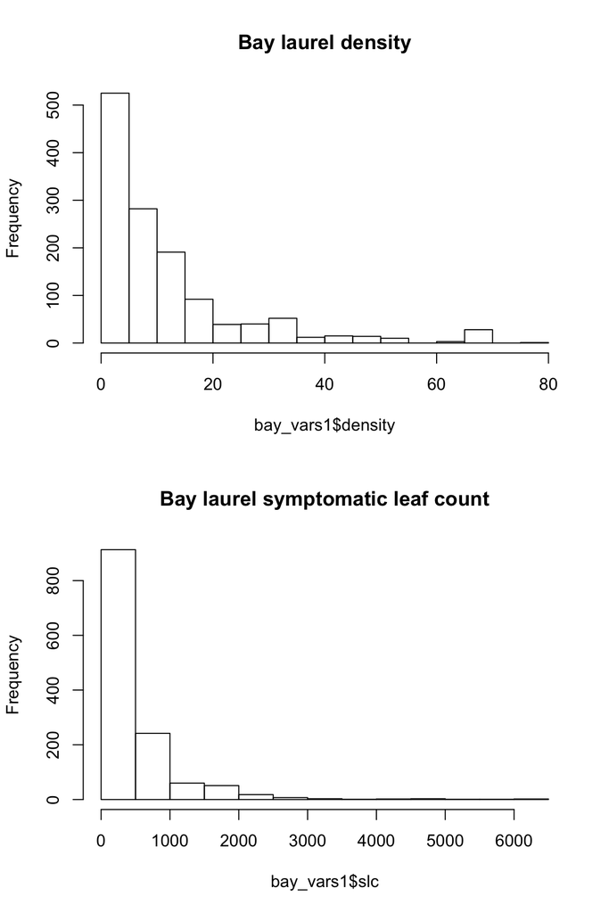

```r
par(mfrow=c(2,1))
hist(bay_vars1$density, main = "Bay laurel density")
hist(bay_vars1$slc, main = "Bay laurel symptomatic leaf count")
```

These show some pretty severe right skew, so I tried a log transformation:

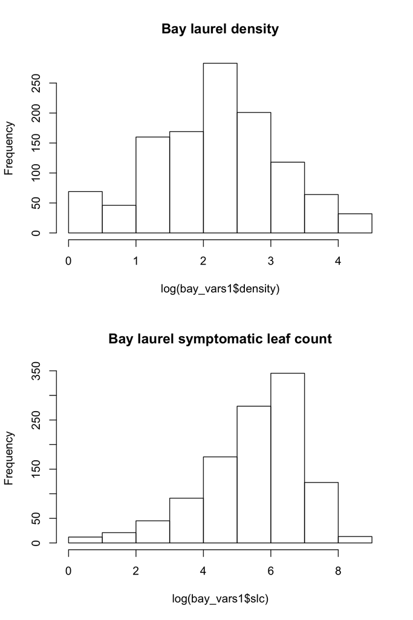

```r
par(mfrow=c(2,1))
hist(log(bay_vars1$density), main = "Bay laurel density")
hist(log(bay_vars1$slc), main = "Bay laurel symptomatic leaf count")
```

These look much better (closer to a normal distribution), so I will log transfrom the variables for the plotting and modeling. I will also need to add one to each variable, because there are some plots where the value for either density or the leaf count is zero.

###### To get started with the plotting by year I created a `ggplot` object using the `qplot` function. The data isn’t structured quite right for what I want to do, so I employed the piping operator and the `group_by` function from the `dplyr` package in the call to `data` in the plotting function. I want the density and leaf count grouped by plot and year, so those go into the function. Now I can use year to create a default color scheme and in the `facet` option to make this a multipanel plot.

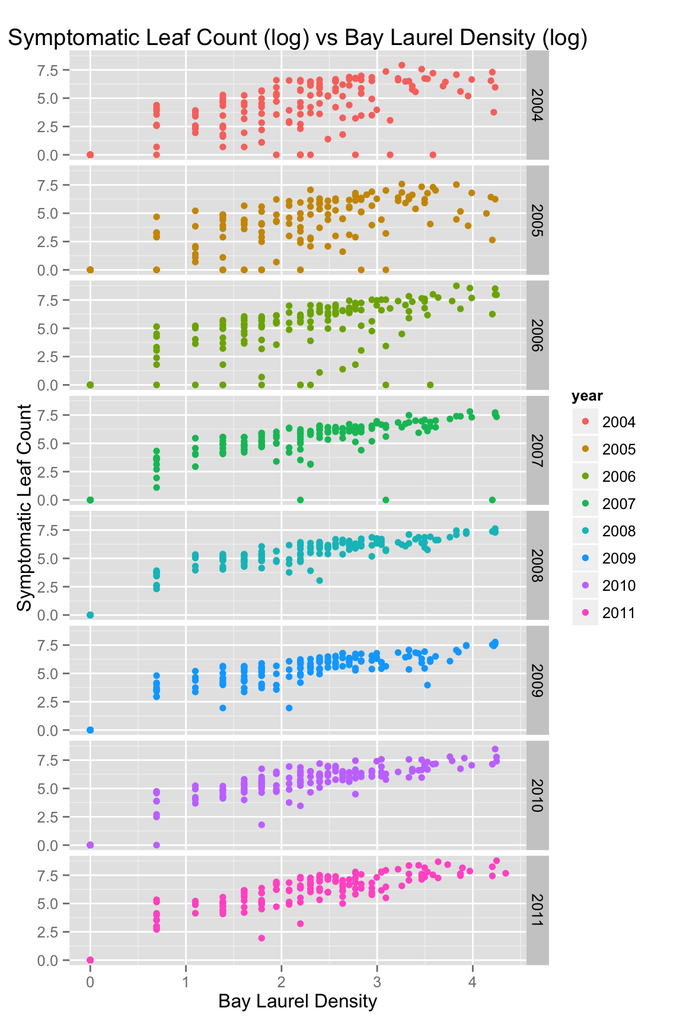

```r
p1 <- qplot(log(density+1), log(slc+1), data = bay_vars1 %>%
                  group_by(plotid, year), color = year, facets = year~.,
            xlab = "Bay Laurel Density", ylab = "Symptomatic Leaf Count",
            main = "Symptomatic Leaf Count (log) vs Bay Laurel Density (log)")
p1
```

This first object is made up of scatter plots showing the log-log relationship between symptomatic leaf count and bay laurel density, with each year getting its own color and panel (facet). You can see that the variance in the relationship between bay laurel density and leaf count appears to decrease through time. But, it is difficult to really judge the magnitude.

###### To address this I started by adding a call to the smoothing function in `ggplot2` based on a linear model of these variables. The gray area around the lines are the estimated standard errors and they do appear to overall decrease through time, but it is difficult to tell if the improvement is really substantial.

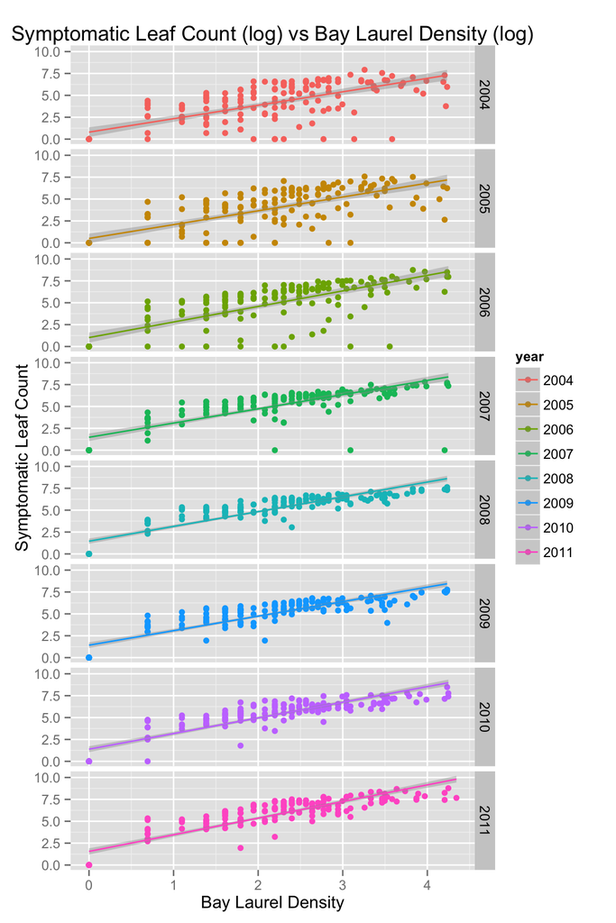

```r
p1 + geom_smooth(aes(group=year), method="lm", size = 0.5)
```

```r
reg_eqn <- function(df) {
      y = log(df$slc+1)
      x = log(df$density+1)
      m <- lm(y ~ x, data = df)

      a <- coef(m)[1]
      b <- coef(m)[2]
      r2 <- summary(m)$r.squared

      expr <- substitute(italic(y) == a + b %.% italic(x)*","~~italic(r)^2~"="~r2,
                         list(a = format(a, digits = 2),
                              b = format(b, digits = 2),
                              r2 = format(r2, digits = 3)))
      c(lab = as.character(as.expression(expr)))
}
eqns <- ddply(bay_vars1, "year", reg_eqn)
```

###### Now I can add the labels using a call to `geom_text` using the data from the `eqns` data frame I just created.

```r
p1 <- p1 + geom_smooth(aes(group=year), method="lm", size = 0.5) +
      geom_text(aes(x = 0, y = 3, label = lab), data = eqns, parse = T,
                hjust = 0, vjust = -1.5)
```

The `x` and `y` in `geom_text` are the coordinates for the initial placement of the labels. I adjusted the horizontal (`hjust`) and vertical (`vjust`) placement after a few plotting attempts. #Note:# It is necessary to have the correct transformation in the call to the `reg_eqn` function

###### I also changed the theme to remove the gray background, discarded the legend because the years are already labeled, and adjusted the margins between the panels. This last adjustment required the `grid` package in order to recognize the unit

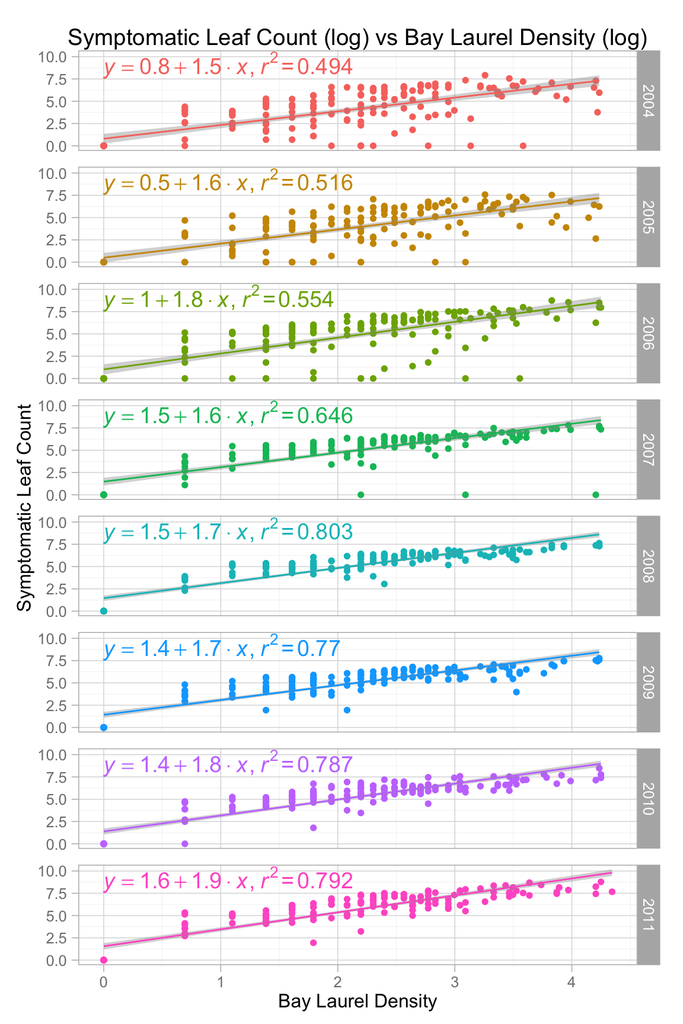

```r
library(grid)
p1 + theme_light() +
      theme(legend.position="none") +
      theme(panel.margin = unit(0.7,"lines")) #`unit` required a specific loading of `grid`
```

###### Finally, I put this all together in a call to `ggplot` instead of starting with `qplot` and added a few other adjustments, most notably, changing the ‘size’ and ‘alpha’ value for the points (`geom_point`) to increase transparency due to the overlap.

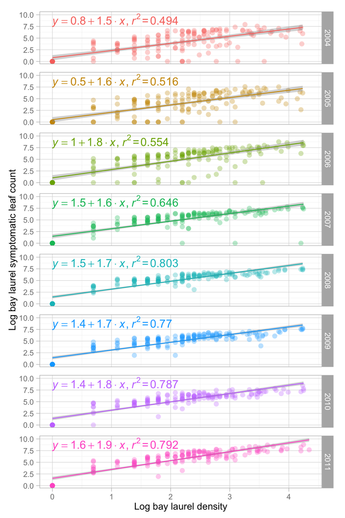

```r
p1 <- ggplot(data = bay_vars1 %>% group_by(year),
              aes(x = log(density+1), y = log(slc+1), color = year)) +
      geom_point(size=3, alpha = 0.3) +
      geom_smooth(method="lm", size = 0.5) +
      geom_text(aes(x = 0, y = 3, label = lab), data = eqns, parse = T,
                hjust = 0, vjust = -1.5) +
      facet_grid(year~.)
p1 + theme_light() +
      theme(legend.position = "none") +
      theme(panel.margin = unit(0.7, "lines")) +
      labs(x = "Log bay laurel density",
           y = "Log bay laurel symptomatic leaf count")
```

Hat-tip @noamross for his blog post here http://www.noamross.net/blog/2013/11/20/formatting-plots-for-pubs.html where a few things about `ggplot` finally became clear.